# Assignment 6

Jes Braun

2/26/2021

**THIS IS MY ATTEMPT AT R MARKDOWN**  
I know what I am doing

# How I built my database

My database is not very fancy because it is all imaginary data at this time. I used SQLite Studio to build my tables and linked them with Primary Keys. You can find that database [here](https://github.com/jesbraun/utah_lake/blob/main/plant_database.db).

I couldn’t figure out how to link the foreign keys, so acknowledge that gap in my database

## This is what my code looked like

CREATE TABLE plant_list ( latin_name char(50), common_name varchar(50), PRIMARY KEY (common_name) );

CREATE TABLE functional_traits ( latin_name varchar(50), growth_rate numb(10), root_length numb(10), horizontal_spread numb(10), PRIMARY KEY (growth_rate) );

CREATE TABLE plant_groups ( latin_name varchar(50), wetland_indicator_status varchar(10), life_cycle varchar(50), dormancy_breaking_strategy varchar(50), PRIMARY KEY (wetland_indicator_status) );

CREATE TABLE seed_collection ( plant_id varchar(50), latin_name char(50), collection_site varchar(10), name_collector char(10), date_collected numb(10), PRIMARY KEY (collection_site) );

CREATE TABLE seed_coating ( plant_id varchar(50), coating_type varchar(10), latin_name char(50), plant_date numb(10), PRIMARY KEY (coating_type) );

CREATE TABLE research_plots ( plot_name char(50), plant_id varchar(50), longitude numb(50), latitude numb(50), PRIMARY KEY (plot_name) );

## This is my schema

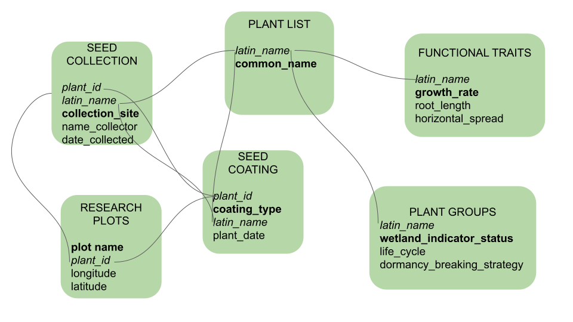

**bold**= primary key. Unique id for each record in that table  
*Italics* = foreign key, a variable shared between tables